# Introduction to the NumPy Stack

# Pandas

Pandas is an open-source library built on top of NumPy. It introduces some new data structures to Python, including the DataFrame, which will be used to store general tabular data. In order to use these tools, we have to import the Pandas library. There is a strong convention in industry to reference Pandas by the shorthand "pd" as follows.

```python
import pandas as pd
```

### Series

Before we get to DataFrames, we're first going to look at another, more basic data structure in Pandas, the Series. A Series is much like a NumPy Array, but a Series is able to have axis labels. This means a Series can now be indexed by a label.

```python
l = [1,2,3]                              # An ordinary Python list
labels = ["a", "b", "c"]                 # A list of "labels"
a = np.array([10, 20, 30])               # A NumPy Array
d = {i:j for i, j in zip(labels, a)}     # An ordinary Python dictionary
```

We're going to use the objects defined above to demonstrate how we can create a Series. First, we can simply pass in our Python list to the argument `data`.

```python
s = pd.Series(data = l)
s
```

```
0    1
1    2
2    3
dtype: int64
```

We see here that the Series has been created with a default index (a sequence of integers starting at 0), since we didn't pass any index labels to the function. If we'd like the Series to have an access label, we simply pass in a list of labels for the function to use.

```python
s = pd.Series(data = l, index = labels)
s
```

```
a    1
b    2
c    3
dtype: int64
```

Now our Series has index labels "a", "b", and "c". We can also use a NumPy array as our data, as follows.

```python
s = pd.Series(data = a, index = labels)
s
```

```
a    10
b    20
c    30
dtype: int32
```

The arguments `data` and `index` are actually positional arguments to the function, so we can just pass them in and Python will know what to do as long as we pass the data first and the label second.

```python
s = pd.Series(a, labels)
s
```

```
a    10
b    20
c    30
dtype: int32
```

Finally, we can also pass a dictionary into the `Series()` function, and it will assign the values as the data and the keys as the index labels.

```python
s = pd.Series(d)
s
```

```
a    10
b    20
c    30
dtype: int64
```

This added feature, the axis label, allows a Pandas Series to very efficiently and easily perform certain operations that would otherwise be more complex to execute. For example, we can now index into a Series using the index label.

```python
s["c"]
```

```
30
```

```python
s[["a", "c"]]
```

```
a    10
c    30
dtype: int64
```

Being built upon NumPy Arrays, Series also support vectorized arithmetic operations, but these already powerful operations can be augmented further by the index label. We see that we can perform vector addition with two Series as follows.

```python
s1 = pd.Series([1,2,3])
s2 = pd.Series([4,5,6])

s1 + s2
```

```
0    5
1    7
2    9
dtype: int64
```

Now let's look at two Series with axis labels.

```python
s1 = pd.Series([1,2,3,4,5], ["USA", "UK", "Canada", "Australia", "France"])
s2 = pd.Series([1,2,3,4,5], ["UK", "USA", "Australia", "France", "Germany"])

s3 = s1 + s2
s3
```

```
Australia    7.0
Canada       NaN
France       9.0
Germany      NaN
UK           3.0
USA          3.0
dtype: float64
```

```python
np.isnan(s3)
```

```
Australia    False
Canada        True
France       False
Germany       True
UK           False
USA          False
dtype: bool
```

Even though each country in `s1` has a different "position" in `s2`, Python was able to match up the values assigned each country and perform this element-wise addition according to the axis label. Notice that the countries that don't appear in both series show up as "Not a Number" (`NaN`). This can be very powerful and convenient for making sure all of our calculations line up as they should while dealing with large data sets.

### DataFrames

While the Pandas Series object has a lot of useful properties and features, the real work horse of data manipulation in Python is the Pandas DataFrame, which is able to store general tabular data. We can generate DataFrames for testing out concepts by casting dictionaries.

```python
d = {i:[j, j+5, j*2] for i,j in zip(labels, a)}
d
```

```
{'a': [10, 15, 20], 'b': [20, 25, 40], 'c': [30, 35, 60]}
```

```python
df = pd.DataFrame(d)
df
```

|  | a | b | c |
| --- | --- | --- | --- |
| 0 | 10 | 20 | 30 |
| 1 | 15 | 25 | 35 |
| 2 | 20 | 40 | 60 |

#### Importing and Exporting Data

Most of the time, in real-world data science applications our DataFrames will be the result of loading in some file given to us by a client (usually in some text format, like a .csv, or an Excel spreadsheet). To appreciate the power of Pandas, let's first look at how we would load in such a data file using only NumPy.

```python
data = []

with open("data_2d.csv") as f:
    for line in f:
        row = line.split(",")
        sample = map(float, row)
        data.append(sample)

data = np.array(data)

data[:10, :]
```

[output not shown]

That wasn't exactly hard, but it wasn't as easy as that could possibly be either. Also, the object `data` is a matrix, so we're restricted in terms of the type of data we can store in it, because all of the elements of a matrix *must* be of the same type. However, we know that a lot of real world data we encounter in industry is a mixture of data types. One column might be numeric, while other columns are categorical variables, dates, or free text. In this case, we definitely need a DataFrame. We can read a file into a DataFrame quite easily. Let's go ahead and load the same data set we just used to create a DataFrame.

```python
data = pd.read_csv("data_2d.csv", header=None)
data.head(10)
```

|  | 0 | 1 | 2 |
| --- | --- | --- | --- |
| 0 | 17.930201 | 94.520592 | 320.259530 |
| 1 | 97.144697 | 69.593282 | 404.634472 |
| 2 | 81.775901 | 5.737648 | 181.485108 |
| 3 | 55.854342 | 70.325902 | 321.773638 |
| 4 | 49.366550 | 75.114040 | 322.465486 |
| 5 | 3.192702 | 29.256299 | 94.618811 |
| 6 | 49.200784 | 86.144439 | 356.348093 |
| 7 | 21.882804 | 46.841505 | 181.653769 |
| 8 | 79.509863 | 87.397356 | 423.557743 |
| 9 | 88.153887 | 65.205642 | 369.229245 |

Now *that* was easy. And the object `data` is now a Pandas DataFrame, which has a number of useful methods and features. We will save the discussion of most methods and features for the next section. However, we will demonstrate now how to write a DataFrame to a csv file.

```python
data.to_csv("data_2d_test_write.csv")
```

Now let's try and read this file back in.

```python
data_test_read = pd.read_csv("data_2d_test_write.csv")
data_test_read.head(10)
```

|  | Unnamed: 0 | 0 | 1 | 2 |
| --- | --- | --- | --- | --- |
| 0 | 0 | 17.930201 | 94.520592 | 320.259530 |
| 1 | 1 | 97.144697 | 69.593282 | 404.634472 |
| 2 | 2 | 81.775901 | 5.737648 | 181.485108 |
| 3 | 3 | 55.854342 | 70.325902 | 321.773638 |
| 4 | 4 | 49.366550 | 75.114040 | 322.465486 |
| 5 | 5 | 3.192702 | 29.256299 | 94.618811 |
| 6 | 6 | 49.200784 | 86.144439 | 356.348093 |
| 7 | 7 | 21.882804 | 46.841505 | 181.653769 |
| 8 | 8 | 79.509863 | 87.397356 | 423.557743 |
| 9 | 9 | 88.153887 | 65.205642 | 369.229245 |

We see that the method also wrote the index as a column in the csv file. When we read the file back in, Pandas created another index, so now we have two. To avoid this, we can use the `index` argument in the `to_csv` method. By default, this argument is set to `True`, but we will set it to `False`.

```python
data.to_csv("data_2d_test_write.csv", index = False)
data_test_read = pd.read_csv("data_2d_test_write.csv")
data_test_read.head(10)
```

|  | 0 | 1 | 2 |
| --- | --- | --- | --- |
| 0 | 17.930201 | 94.520592 | 320.259530 |
| 1 | 97.144697 | 69.593282 | 404.634472 |
| 2 | 81.775901 | 5.737648 | 181.485108 |
| 3 | 55.854342 | 70.325902 | 321.773638 |
| 4 | 49.366550 | 75.114040 | 322.465486 |
| 5 | 3.192702 | 29.256299 | 94.618811 |
| 6 | 49.200784 | 86.144439 | 356.348093 |
| 7 | 21.882804 | 46.841505 | 181.653769 |
| 8 | 79.509863 | 87.397356 | 423.557743 |
| 9 | 88.153887 | 65.205642 | 369.229245 |

Now when we read the file back in, we see that we don't have the pesky redundant indexes.

Another common data format we encounter in industry is the Excel workbook. An Excel workbook can be thought of as a collection of "Sheets", and each Sheet can be thought of as a table (read DataFrame). To read data directly from an Excel file, we will need the package `xlrd`, which should come with the Anaconda distribution. If you don't have it, simply open the command prompt or terminal and type the following command.

`conda install xlrd`

Or, if you're not using Anaconda, use the normal pip install.

`pip install xlrd`

```python
import xlrd

data = pd.read_excel("excel_sample.xlsx", sheetname = "Sheet1")
data.head(10)
```

|  | A | B | C |
| --- | --- | --- | --- |
| 0 | 17.930201 | 94.520592 | 320.259530 |
| 1 | 97.144697 | 69.593282 | 404.634472 |
| 2 | 81.775901 | 5.737648 | 181.485108 |
| 3 | 55.854342 | 70.325902 | 321.773638 |
| 4 | 49.366550 | 75.114040 | 322.465486 |
| 5 | 3.192702 | 29.256299 | 94.618811 |
| 6 | 49.200784 | 86.144439 | 356.348093 |
| 7 | 21.882804 | 46.841505 | 181.653769 |
| 8 | 79.509863 | 87.397356 | 423.557743 |
| 9 | 88.153887 | 65.205642 | 369.229245 |

Keep in mind that an Excel workbook may contain all kinds of structures under the hood, such as formulas, images, and macros. Pandas can't read in these aspects of an Excel workbook, it can only read the data values in the cells. When trying to read an Excel sheet with these aspects, best case scenario, it won't work and Python will simply read in the data, worst case scenario, Python will crash.

To save a DataFrame as an Excel file, simply call the corresponding method.

```python
data.to_excel("excel_sample_write_test.xlsx", sheet_name = "Test")
```

```python
data_test_read = pd.read_excel("excel_sample_write_test.xlsx", sheetname = "Test")
data_test_read.head(10)
```

|  | A | B | C |
| --- | --- | --- | --- |
| 0 | 17.930201 | 94.520592 | 320.259530 |
| 1 | 97.144697 | 69.593282 | 404.634472 |
| 2 | 81.775901 | 5.737648 | 181.485108 |
| 3 | 55.854342 | 70.325902 | 321.773638 |
| 4 | 49.366550 | 75.114040 | 322.465486 |
| 5 | 3.192702 | 29.256299 | 94.618811 |
| 6 | 49.200784 | 86.144439 | 356.348093 |
| 7 | 21.882804 | 46.841505 | 181.653769 |
| 8 | 79.509863 | 87.397356 | 423.557743 |
| 9 | 88.153887 | 65.205642 | 369.229245 |

Pandas can also retrieve data from sources on the internet. For this example, let's navigate to the web page https://www.fdic.gov/bank/individual/failed/banklist.html. This page contains a table of failed banks with some additional information about the bank, such as the city, the bank's certification number, and when they failed. Pandas can actually retrieve this table directly from the web page.

```python
data = pd.read_html("https://www.fdic.gov/bank/individual/failed/banklist.html")
```

Let's check to see the type of our object `data`.

```python
type(data)
```

```
list
```

We see that `data` is actually an ordinary Python `list` instead of a DataFrame. What the function `pd.read_html` has done is parse the entire web page looking for table markers. Everywhere that the parser found a table marker in the html, it parsed the table and then stored that information in a list. We now have to check what is in our list to see if we got what we were looking for.

```python
len(data)
```

```
1
```

Luckily, we see that in this case the function only found one table, so we can simply extract it from our list as follows.

```python
data = data[0]
data.head(10)
```

|  | Bank Name | City | ST | CERT | Acquiring Institution | Closing Date | Updated Date |
| --- | --- | --- | --- | --- | --- | --- | --- |
| 0 | Washington Federal Bank for Savings | Chicago | IL | 30570 | Royal Savings Bank | December 15, 2017 | February 21, 2018 |
| 1 | The Farmers and Merchants State Bank of Argonia | Argonia | KS | 17719 | Conway Bank | October 13, 2017 | February 21, 2018 |
| 2 | Fayette County Bank | Saint Elmo | IL | 1802 | United Fidelity Bank, fsb | May 26, 2017 | July 26, 2017 |
| 3 | Guaranty Bank, (d/b/a BestBank in Georgia & Mi... | Milwaukee | WI | 30003 | First-Citizens Bank & Trust Company | May 5, 2017 | March 22, 2018 |
| 4 | First NBC Bank | New Orleans | LA | 58302 | Whitney Bank | April 28, 2017 | December 5, 2017 |
| 5 | Proficio Bank | Cottonwood Heights | UT | 35495 | Cache Valley Bank | March 3, 2017 | March 7, 2018 |
| 6 | Seaway Bank and Trust Company | Chicago | IL | 19328 | State Bank of Texas | January 27, 2017 | May 18, 2017 |
| 7 | Harvest Community Bank | Pennsville | NJ | 34951 | First-Citizens Bank & Trust Company | January 13, 2017 | May 18, 2017 |
| 8 | Allied Bank | Mulberry | AR | 91 | Today's Bank | September 23, 2016 | September 25, 2017 |
| 9 | The Woodbury Banking Company | Woodbury | GA | 11297 | United Bank | August 19, 2016 | June 1, 2017 |

Please note that there are a lot of file formats out there (JSON, FWF, SAS, STATA, and many more), and Pandas has functions to read each of these formats. The ones shown here are simply the most commonly encountered. Pandas can also read data using SQL queries, but we'll cover this in detail when we cover SQL. For now we will move on to the methods of DataFrames.

#### Basic DataFrame Methods

The first method you might've noticed is the `head(n=5)` method. This allows us to get a quick glimpse at the structure of our table without trying to display the entire thing. The default is for `head()` to output the first five rows of the DataFrame, but we can change the number of rows output by simply passing the number of rows we want to the method.

```python
data.head()
```

|  | Bank Name | City | ST | CERT | Acquiring Institution | Closing Date | Updated Date |
| --- | --- | --- | --- | --- | --- | --- | --- |
| 0 | Washington Federal Bank for Savings | Chicago | IL | 30570 | Royal Savings Bank | December 15, 2017 | February 21, 2018 |
| 1 | The Farmers and Merchants State Bank of Argonia | Argonia | KS | 17719 | Conway Bank | October 13, 2017 | February 21, 2018 |
| 2 | Fayette County Bank | Saint Elmo | IL | 1802 | United Fidelity Bank, fsb | May 26, 2017 | July 26, 2017 |
| 3 | Guaranty Bank, (d/b/a BestBank in Georgia & Mi... | Milwaukee | WI | 30003 | First-Citizens Bank & Trust Company | May 5, 2017 | March 22, 2018 |
| 4 | First NBC Bank | New Orleans | LA | 58302 | Whitney Bank | April 28, 2017 | December 5, 2017 |

Now let's look at basic methods for querying DataFrames for information. Here we will use the iris data set.

```python
iris_df = pd.read_csv("iris.csv")
iris_df.head()
```

|  | Sepal.Length | Sepal.Width | Petal.Length | Petal.Width | Species |
| --- | --- | --- | --- | --- | --- |
| 0 | 5.1 | 3.5 | 1.4 | 0.2 | setosa |
| 1 | 4.9 | 3.0 | 1.4 | 0.2 | setosa |
| 2 | 4.7 | 3.2 | 1.3 | 0.2 | setosa |
| 3 | 4.6 | 3.1 | 1.5 | 0.2 | setosa |
| 4 | 5.0 | 3.6 | 1.4 | 0.2 | setosa |

First, we may want to format the names of our columns to better fit the style of the Python language. There is also a more practical consideration in doing this. Here we see that most of our column names contain the "." character. This character is also used to call methods, and we don't want the Python interpreter to confuse part of a column name with a method. This will almost certainly lead to errors that crash the Python interpreter, and may even lead to unexpected results. We proceed with the rename method as follows.

```python
iris_df \
    .rename(
        columns = {
            "Sepal.Length":"sepal_length",
            "Sepal.Width":"sepal_width",
            "Petal.Length":"petal_length",
            "Petal.Width":"petal_width",
            "Species":"species"},
        inplace = True
    )
```

```python
iris_df.head()
```

|  | sepal_length | sepal_width | petal_length | petal_width | species |
| --- | --- | --- | --- | --- | --- |
| 0 | 5.1 | 3.5 | 1.4 | 0.2 | setosa |
| 1 | 4.9 | 3.0 | 1.4 | 0.2 | setosa |
| 2 | 4.7 | 3.2 | 1.3 | 0.2 | setosa |
| 3 | 4.6 | 3.1 | 1.5 | 0.2 | setosa |
| 4 | 5.0 | 3.6 | 1.4 | 0.2 | setosa |

Now that our columns are named as we would like them, we can look at methods for basic queries into the data. We've seen that DataFrames are very similar to Python dictionaries. Recall that a dictionary can be cast directly as a Pandas DataFrame and the keys will be interpreted as the column names, while the values will be taken as the columns themselves. We can extend this analogy a little further by calling a column from our DataFrame in the same way we would call a value by its key name in a dictionary.

```python
iris_df["sepal_length"].head()
```

```
0    5.1
1    4.9
2    4.7
3    4.6
4    5.0
Name: sepal_length, dtype: float64
```

Let's see the exact nature of this output.

```python
type(iris_df["sepal_length"])
```

```
pandas.core.series.Series
```

We see that each individual column in a Pandas DataFrame is actually a Pandas Series. So, a DataFrame is just a collection of Series which share the same index. It turns out the rows of the DataFrame can be thought of in this way as well.

```python
iris_df.iloc[0]
```

```
sepal_length       5.1
sepal_width        3.5
petal_length       1.4
petal_width        0.2
species         setosa
Name: 0, dtype: object
```

```python
type(iris_df.iloc[0])
```

```
pandas.core.series.Series
```

Each row is a Pandas Series indexed by the column names in the DataFrame.

We can also call multiple columns at once by passing a list of column names into the brackets. We will see that in this case the result is also a Pandas DataFrame, which is a sub frame of the original DataFrame.

```python
iris_df[["sepal_length", "sepal_width"]].head()
```

|  | sepal_length | sepal_width |
| --- | --- | --- |
| 0 | 5.1 | 3.5 |
| 1 | 4.9 | 3.0 |
| 2 | 4.7 | 3.2 |
| 3 | 4.6 | 3.1 |
| 4 | 5.0 | 3.6 |

```python
type(iris_df[["sepal_length", "sepal_width"]])
```

```
pandas.core.frame.DataFrame
```

Now let's look at methods for subsetting the rows of a DataFrame. We just saw in the above example that we can call rows by their index value using the `iloc` method. Think of the `loc` as being "location", and the `i` as "index." So this method is for calling the index location of the desired row(s).

```python
iris_df.iloc[10]
```

```
sepal_length       5.4
sepal_width        3.7
petal_length       1.5
petal_width        0.2
species         setosa
Name: 10, dtype: object
```

```python
iris_df.iloc[0:12]
```

|  | sepal_length | sepal_width | petal_length | petal_width | species |
| --- | --- | --- | --- | --- | --- |
| 0 | 5.1 | 3.5 | 1.4 | 0.2 | setosa |
| 1 | 4.9 | 3.0 | 1.4 | 0.2 | setosa |
| 2 | 4.7 | 3.2 | 1.3 | 0.2 | setosa |
| 3 | 4.6 | 3.1 | 1.5 | 0.2 | setosa |
| 4 | 5.0 | 3.6 | 1.4 | 0.2 | setosa |
| 5 | 5.4 | 3.9 | 1.7 | 0.4 | setosa |
| 6 | 4.6 | 3.4 | 1.4 | 0.3 | setosa |
| 7 | 5.0 | 3.4 | 1.5 | 0.2 | setosa |
| 8 | 4.4 | 2.9 | 1.4 | 0.2 | setosa |
| 9 | 4.9 | 3.1 | 1.5 | 0.1 | setosa |
| 10 | 5.4 | 3.7 | 1.5 | 0.2 | setosa |
| 11 | 4.8 | 3.4 | 1.6 | 0.2 | setosa |

We can use slice notation to call ranges of rows in a DataFrame. Just as with columns, when we call a single row, we get a Series; when we call multiple rows, we get a DataFrame. We can also use the method to call columns after subsetting rows, so we can subset our DataFrame in multiple ways simultaneously.

```python
iris_df.iloc[0:10]["sepal_length"]
```

```
0    5.1
1    4.9
2    4.7
3    4.6
4    5.0
5    5.4
6    4.6
7    5.0
8    4.4
9    4.9
Name: sepal_length, dtype: float64
```

```python
iris_df.iloc[0:10][["sepal_length", "sepal_width"]]
```

|  | sepal_length | sepal_width |
| --- | --- | --- |
| 0 | 5.1 | 3.5 |
| 1 | 4.9 | 3.0 |
| 2 | 4.7 | 3.2 |
| 3 | 4.6 | 3.1 |
| 4 | 5.0 | 3.6 |
| 5 | 5.4 | 3.9 |
| 6 | 4.6 | 3.4 |
| 7 | 5.0 | 3.4 |
| 8 | 4.4 | 2.9 |
| 9 | 4.9 | 3.1 |

Often we won't be subsetting our DataFrames using row indexes, but rather with logical conditions. For this we will use the `loc` method to simply find the locations that match our condition(s).

```python
iris_df.loc[iris_df["sepal_length"] > 5].head()
```

|  | sepal_length | sepal_width | petal_length | petal_width | species |
| --- | --- | --- | --- | --- | --- |
| 0 | 5.1 | 3.5 | 1.4 | 0.2 | setosa |
| 5 | 5.4 | 3.9 | 1.7 | 0.4 | setosa |
| 10 | 5.4 | 3.7 | 1.5 | 0.2 | setosa |
| 14 | 5.8 | 4.0 | 1.2 | 0.2 | setosa |
| 15 | 5.7 | 4.4 | 1.5 | 0.4 | setosa |

```python
iris_df.loc[(iris_df["sepal_length"] > 5) & (iris_df["sepal_width"] > 4)]
```

|  | sepal_length | sepal_width | petal_length | petal_width | species |
| --- | --- | --- | --- | --- | --- |
| 15 | 5.7 | 4.4 | 1.5 | 0.4 | setosa |
| 32 | 5.2 | 4.1 | 1.5 | 0.1 | setosa |
| 33 | 5.5 | 4.2 | 1.4 | 0.2 | setosa |

We can also use these methods to simultaneously call rows and columns, but we must use the same method in both axes to do this. That is, we must use index values when using `iloc`, and we must use conditions and key values when using `loc`.

```python
iris_df.iloc[0:10, 0:]
```

|  | sepal_length | sepal_width | petal_length | petal_width | species |
| --- | --- | --- | --- | --- | --- |
| 0 | 5.1 | 3.5 | 1.4 | 0.2 | setosa |
| 1 | 4.9 | 3.0 | 1.4 | 0.2 | setosa |
| 2 | 4.7 | 3.2 | 1.3 | 0.2 | setosa |
| 3 | 4.6 | 3.1 | 1.5 | 0.2 | setosa |
| 4 | 5.0 | 3.6 | 1.4 | 0.2 | setosa |
| 5 | 5.4 | 3.9 | 1.7 | 0.4 | setosa |
| 6 | 4.6 | 3.4 | 1.4 | 0.3 | setosa |
| 7 | 5.0 | 3.4 | 1.5 | 0.2 | setosa |
| 8 | 4.4 | 2.9 | 1.4 | 0.2 | setosa |
| 9 | 4.9 | 3.1 | 1.5 | 0.1 | setosa |

```python
iris_df.loc[
    (iris_df["sepal_length"] > 5) &
    (iris_df["sepal_width"] > 4),
    ["petal_length",
     "petal_width",
     "species"]]
```

|  | petal_length | petal_width | species |
| --- | --- | --- | --- |
| 15 | 1.5 | 0.4 | setosa |
| 32 | 1.5 | 0.1 | setosa |
| 33 | 1.4 | 0.2 | setosa |

```python
iris_df.iloc[0:10, "sepal_width"]
```

```python
iris_df.loc[iris_df["sepal_width"] > 4, 3]
```

Pandas DataFrames also have some built-in methods for handling missing data. This is an important consideration in any real world data science project.

```python
iris_df.dropna(inplace = True)

iris_df \
    .loc["sepal_length"] \
    .fillna(iris_df["sepal_length"].mean())
```

#### Two-Table Verbs

```python
pd.merge(df1, df2, by=["vars"], how="what type of join (left, right, inner, full)")
```

```python
df = pd.DataFrame(
    {"subject":["Math", "Biology", "Western Civilization"],
    "Mid1":[99, 98, 100],
    "Mid2":[92, 97, 99],
    "Final":[99, 98, 100]})
df.head()
```

|  | Final | Mid1 | Mid2 | subject |
| --- | --- | --- | --- | --- |
| 0 | 99 | 99 | 92 | Math |
| 1 | 98 | 98 | 97 | Biology |
| 2 | 100 | 100 | 99 | Western Civilization |

```python
pd.melt(df, id_vars="subject",
        value_vars=["Mid1", "Mid2", "Final"],
        var_name = "exam",
        value_name = "score")
```

|  | subject | exam | score |
| --- | --- | --- | --- |
| 0 | Math | Mid1 | 99 |
| 1 | Biology | Mid1 | 98 |
| 2 | Western Civilization | Mid1 | 100 |
| 3 | Math | Mid2 | 92 |
| 4 | Biology | Mid2 | 97 |
| 5 | Western Civilization | Mid2 | 99 |
| 6 | Math | Final | 99 |
| 7 | Biology | Final | 98 |
| 8 | Western Civilization | Final | 100 |

### matplotlib

```python
import matplotlib.pyplot as plt
import seaborn as sn; sn.set()
%matplotlib inline
```

```python
x = np.linspace(0, 10, 100)
y = 2.7 + 1.4*x + np.random.randn(100)
```

[output not shown]

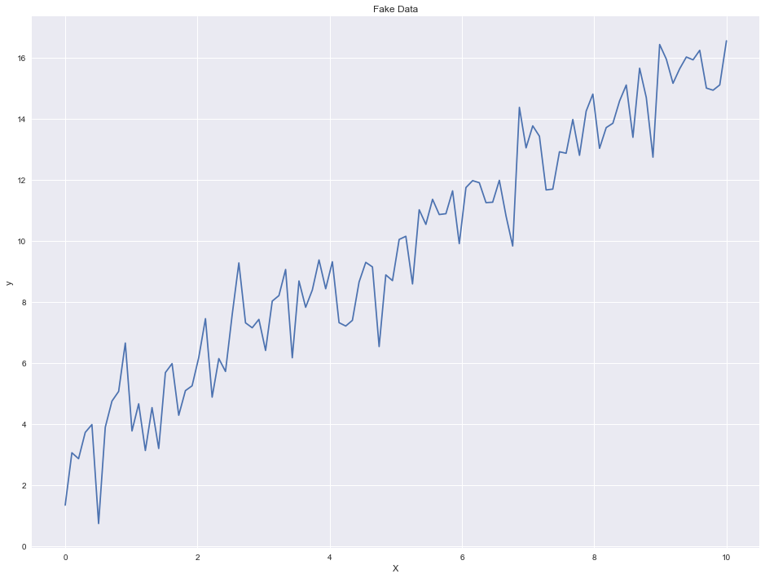

```python
plt.figure(figsize=(16,12))
plt.plot(x, y)
plt.xlabel("X")
plt.ylabel("y")
plt.title("Fake Data")
plt.show()
```

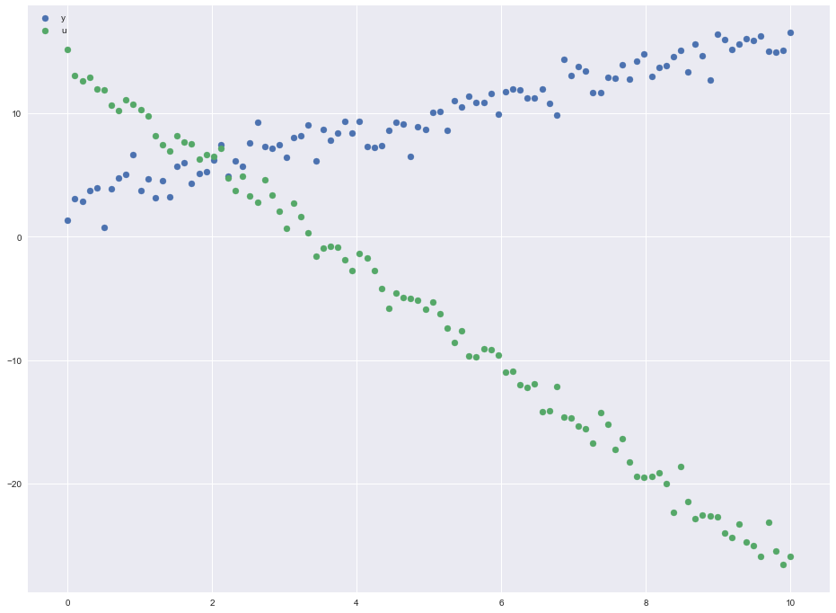

```python
u = 14 - 4.1*x + np.random.randn(100)

plt.figure(figsize=(16,12))
plt.scatter(x,y, label = "y")
plt.scatter(x,u, label = "u")
plt.legend()
```

```
Text(0.5,0,u'This is whatever z is')
```

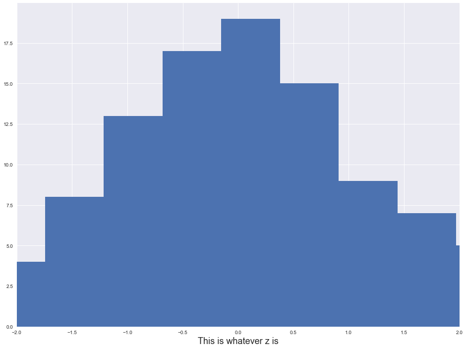

```python
z = np.random.randn(100)

plt.figure(figsize=(16,12))
plt.hist(z)
plt.xlim((-2,2))
plt.xlabel("This is whatever z is", fontsize = 18)
```